# Political Promise Evaluation (PPE)

#### NLP CS6120

##### By: Bhanu Jain, Rohit Begani

# Problem

#### Track performance of political leaders through continous evaluation of promises made during election campaign

[figure not shown]

# Data

## Promises

- Trump Tracker API

## Promise Evaluation

- Twiiter
- NYT
- Google Search

# Promises

```python
with open("out/promises.json") as data_file:
    p_data = json.load(data_file)

len(p_data)
```

```
174
```

```python
print(json.dumps(p_data[0],indent=4, sort_keys=True))
```

```
{
    "promise_description": "",
    "promise_tag": [
        "Contract with the American Voter - 100 Day Plan"
    ],
    "promise_title": "Propose a Constitutional Amendment to impose term limits on all members of Congress"
}
```

```python
promises = get_promise_token()
for k,v in promises.items():
    print(k+":\n"+v+"\n")
```

```
Repeal and Replace Obamacare Act:
fully repeals obamacare and replaces it with health savings accounts the ability to purchase health insurance across state lines and lets states manage medicaid funds reforms will also include cutting the red tape at the fda there are over 4000 drugs awaiting approval and we especially want to speed…

Build a wall. Trump's campaign began with a promise to build a wall across the United States' southern border and deport the country's 11 million undocumented immigrants.:
build a wall trumps campaign began with a promise to build a wall across the united states southern border and deport the countrys 11 million undocumented immigrants
```

# Twitter

```python
tweets = TwitterMiner().login().search.tweets(q="#trump", count=5)
for tweet in tweets['statuses']:
    print(tweet['text'])
```

```
Don't talk crap..

At least stand in respectful solidarity with the majority Syrian population &amp; their demands. You… https://t.co/7RJZtkqNqW
RT @RawStory: #RussiaRussiaRussia. #Trump has turned into #JanBrady. https://t.co/vDQQH3QPQ1
RT @ToDropADime2: If your Husband or Wife Lied to you 5 times a day, would you stay with them?

#Trump Lies 5.5 times a day......
RT @haaretzcom: Trump Tweets anti-Semitic, Conspiracy Theorist Website Boasting About His Accomplishments
https://t.co/grh6SN1PVx
#Trump #A…
```

# NYT

### Articles

```python
nm = NewsMiner()
articles = nm.get_articles("Donald Trump", "20170730", "20170830")
nm.get_text(articles)
print(json.dumps(articles[0]['text'][:300],indent=4, sort_keys=True))
```

```
"In Damac, Mr. Trump\u2019s company has found a like-minded partner, one that has emblazoned its name across skyscrapers.\n\nAdvertisement Continue reading the main story\n\nThe company\u2019s founder, Hussain Sajwani, has a net worth estimated at around $4 billion, earning him the nickname \u201cth…
```

### Summary and Keywords

```python
print(json.dumps(articles[0]['summary'],indent=4, sort_keys=True))
```

```
"He and his family spent New Year\u2019s Eve with Mr. Trump at his Florida resort, and he attended the president\u2019s inauguration.\nIn an interview with The Times last year, Mr. McLoughlin, the Damac spokesman, said Mr. Trump had visited Damac Hills several times.\nBuilding anything in Dubai inva…
```

```python
print(articles[0]['keywords_1'])
```

```
['wages', 'reading', 'dubai', 'course', 'golf', 'trump', 'workers', 'main', 'donald', 'hills', 'damac', 'late', 'mr', 'migrant']
```

```python
articles = get_article_token()
print("Total Articles Len = %s" %(len(articles)))
```

```
Total Articles Len = 130
```

```python
print("Key: %s" %list(articles.keys())[0])
print("Text: %s" %articles[list(articles.keys())[0]][:300])
```

```
Key: 59934a3d95d0e0246f1ffdc7
Text: the exodus began monday when merck s chief executive said he was resigning from mr trump s manufacturing council citing the president s tepid early statement on the violence in charlottesville where white nationalists staged a weekend march that turned violent on tuesday the leaders of a labor…
```

# Google Search Summary

```python
gm = GoogleMiner()
data = defaultdict(lambda: [])
for s in gm.get_search_summary(promises[list(promises.keys())[0]], 1):
    text = s.text
    tokens = tokenize(text)
    data[list(promises.keys())[0]].append(" ".join(remove_stop_words(tokens)))
print(json.dumps(dict(data),indent=4))
```

```
{
    "Repeal and Replace Obamacare Act": [
        "nov 11 2016 get health insurance affordable care act without id obamacare replaces health saving account ability purchase health insurance across state line let state manage medicaid fund reform also include cutting red tape fda"
    ]
}
```

# UCI Bag of Words Data Set

### NYTimes news Articles

- D=300000
- W=102660
- N=100,000,000 (approx)
- Unlabelled
- Tokenized, Stopwords Removes, Freq > 10
- Will be used to Train

# Methodology

# Article Text Sentiment

## Document Matching

- Bag of Words
- Tf-Idf

## Sentiment Analysis

- Naive Bayes (NTLK - Pre trained)
- Pattern (Lexical)
- Naive Bayes (Custom Trained Classifier)

# Article Summary Sentiment

## Document Matching

- Bag of Words
- Tf-Idf

## Sentiment Analysis

- Naive Bayes (NTLK - Pre trained)
- Pattern (Lexical)
- Naive Bayes (Custom Trained Classifier)

# Google Summary Sentiment

## Search Summary

- Summary for Top 100 Search results

## Sentiment Analysis

- Naive Bayes (NTLK - Pre trained)
- Pattern (Lexical)
- Naive Bayes (Custom Trained Classifier)

# Document Matching

- Create Vocabulary from both Promises and Test Aricles
- Compute tf-idf for all documents
- Get top 5 machted articles for each promise

# Sentiment Analysis

## Naive Bayes (NLTK)

- Pretrained on Movie Reviews

## Pattern

- Lexicon of Adjectives
- Scores for sentiment polarity for each Lexicon
- Subjectivity for each Lexicon

# Trained Naive Bayes Classifier

- Label UCI dataset with Vader Sentiment Analysis
- Classify test articles retrieved from NYT

## Vader

- Vader is a rule-based model
- Valence-Aware Sentiment Lexicon
- Five huristics
  - punctuation
  - capitalization
  - modifiers
  - negation
  - trigram

*Ref: http://comp.social.gatech.edu/papers/icwsm14.vader.hutto.pdf*

# Experiments

- Article Text with NB
- Article Text with Pattern
- Article Summary with NB
- Article Summary with Pattern
- Google Result Summary with NB
- Google Result Summary with Pattern

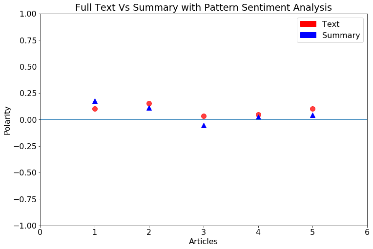

```python
experiment_1()
```

## Promise

```python
 res['article_text_pattern'][0]['promise']
```

```
'Repeal and Replace Obamacare Act'
```

### Top Words for Article 3

```python
from collections import Counter
print(Counter(remove_stop_words(tokenize(res['article_text_pattern'][0]['result'][2]['text']))).most_common(10))
```

```
[('mr', 18), ('bill', 16), ('senator', 16), ('republican', 11), ('wa', 10), ('care', 9), ('house', 9), ('would', 8), ('white', 8), ('leader', 7)]
```

```python
print(Counter(remove_stop_words(tokenize(res['article_summary_pattern'][0]['result'][2]['text'])))
      .most_common(10))
```

```
[('white', 4), ('house', 4), ('health', 3), ('care', 3), ('bill', 3), ('wa', 2), ('mr', 2), ('announced', 1), ('wanted', 1), ('republican', 1)]
```

## ADJ Count for Article 3

```python
tags=nltk.pos_tag(remove_stop_words(tokenize(res['article_text_pattern'][0]['result'][2]['text'])))
print ("Total ADJ in Text : %s" %Counter(tag for word,tag in tags)['JJ'])
Counter([word for word,tag in tags if tag=='JJ']).most_common(5)
```

```
Total ADJ in Text : 154
```

```
[('republican', 11), ('white', 8), ('new', 5), ('senate', 4), ('main', 3)]
```

```python
tags=nltk.pos_tag(remove_stop_words(tokenize(
    res['article_summary_pattern'][0]['result'][2]['text'])))
print ("Total ADJ in Summary : %s" %Counter(tag for word,tag in tags)['JJ'])
Counter([word for word,tag in tags if tag=='JJ']).most_common(5)
```

```
Total ADJ in Summary : 19
```

```
[('white', 4), ('late', 1), ('republican', 1), ('come', 1), ('judged', 1)]
```

## Subjectivity for Article 3

```python
res['article_summary_pattern'][0]['result'][2]['sentiment']['subjectivity']
```

```
0.3151515151515151
```

```python
res['article_text_pattern'][0]['result'][2]['sentiment']['subjectivity']
```

```
0.3747686221824153
```

### Lexicons ADJ in Pattern SA

```
<word form="angry" wordnet_id="a-01173697" pos="JJ" sense="severely inflamed and painful" polarity="-0.5" subjectivity="1.0" intensity="1.0" confidence="0.9" />

<word form="best" wordnet_id="a-00067379" pos="JJ" sense="(comparative and superlative of 'well') wiser or more advantageous and hence advisable" polarity="1.0" subjectivity="0.3" intensity="1.0" confidence="0.9" />

<word form="better" cornetto_synset_id="n_a-503853" wordnet_id="a-01471260" pos="JJ" sense="more than half" polarity="0.5" subjectivity="0.5" intensity="1.0" confidence="0.9" />
```

Ref: *https://github.com/clips/pattern/blob/master/pattern/text/en/en-sentiment.xml*

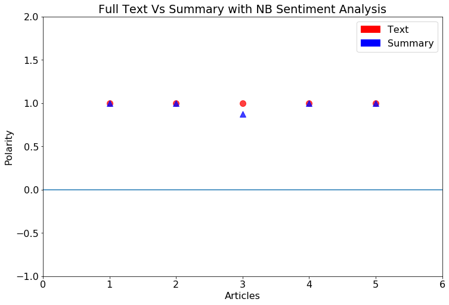

```python
experiment_2()
```

# Evaluation

- For evaluation we used existing data online to check the accuracy of our implementation.
- We matched our results with the status of the promises on TrumpTracker.

| Methodology | Repeal and Replace Obamacare | Build a Wall |
| --- | --- | --- |
| Article Text Pattern | Positive | Positive |
| Google Pattern | Positive | Negative |
| Article Text NB | Positive | Positive |
| Article Summary NB | Positive | Positive |
| Google NB | Positive | Positive |
| Article Summary Pattern | Positive | Negative |
| Actual | Negative | Positive |

# What's Next

- Train a custom classifier on News Dataset with possitive sentiment from lexicons like `completed`, `done` etc. which corresponds to the progress.
- Is subjectivity better for us? Classify subjective and objective sentences and experiment with Objectivity Analysis
- Full Text or Summary?
- Experiment with ABSA